# 예측방법론 5장

### 1. 관련된 패키지 불러오기

```r
list_packages = c("forecast", "lubridate", "quantmod", "readxl", "reshape2", "scales", "tidyverse","xts", "zoo", "tseries", "urca","TSA", "FinTS", "fGarch")

new_packages  = list_packages[!(list_packages %in% installed.packages()[,"Package"])]
if(length(new_packages)) install.packages(new_packages)

invisible(lapply(list_packages, library, character.only = TRUE))
```

### 제5장

#### 그림 5-1 로그변환 및 로그차분변환된 상품 소비자물가지수의 추이

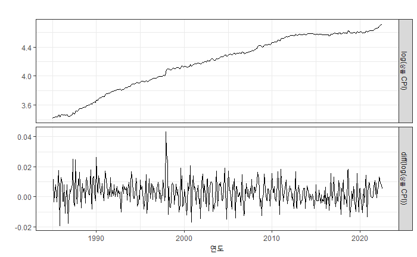

```r
cpi = read_excel("./data/데이터.xlsx", sheet="소비자물가")
cpi_ts = cpi[,3] %>% ts(start=1985, frequency=12)

cbind("log(상품 CPI)"=log(cpi_ts), "diff(log(상품 CPI))"=diff(log(cpi_ts))) %>%
autoplot(facets=TRUE) +
    xlab("연도") + ylab("") + ggtitle("") + theme_bw()
```

#### <프로그램 5-1>

```r
cpi_ts %>% log() %>% adf.test()
```

```
    Augmented Dickey-Fuller Test

data:  .
Dickey-Fuller = -1.2654, Lag order = 7, p-value = 0.8884
alternative hypothesis: stationary
```

```r
cpi_ts %>% log() %>% diff() %>% adf.test()
```

```
    Augmented Dickey-Fuller Test

data:  .
Dickey-Fuller = -6.3547, Lag order = 7, p-value = 0.01
alternative hypothesis: stationary
```

#### 그림 5-2 ARMA(1,1) 모형의 시차도표

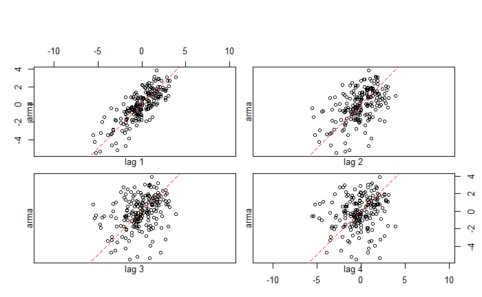

```r
library(TSA)
set.seed(123456)
nn = 200
arma = arima.sim(n=nn, model=list(ar=0.6, ma=0.6))
lag.plot(arma, set.lags = c(1:4), pch = 21, main = "", diag.col = "red")
```

#### 그림 5-3 TAR(1) 모형의 시차도표

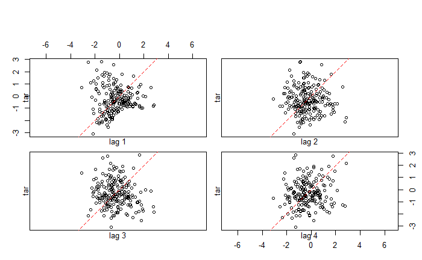

```r
tar = tar.sim(n=nn, Phi1=c(0,0.5), Phi2=c(0, -0.6), p=1, d=1, sigma1=0.5, thd = -1, sigma2=1)$y
 lag.plot(tar, set.lags = c(1:4), pch = 21, main = "", diag.col = "red")
```

#### 비선형 검정: 표 5-1 키넌검정과 체이검정

```r
Keenan.test(arma)
```

```
$test.stat
[1] 0.9731977

$p.value
[1] 0.3251386

$order
[1] 4
```

```r
Tsay.test(arma)
```

```
$test.stat
[1] 1.764

$p.value
[1] 0.07005

$order
[1] 4
```

```r
Keenan.test(tar)
```

```
$test.stat
[1] 4.027463

$p.value
[1] 0.04621332

$order
[1] 6
```

```r
Tsay.test(tar)
```

```
$test.stat
[1] 2.903

$p.value
[1] 7.594e-05

$order
[1] 6
```

#### 그림 5-4 종합주가지수 수익률 제곱의 추이와 맥러드–리 검정 결과

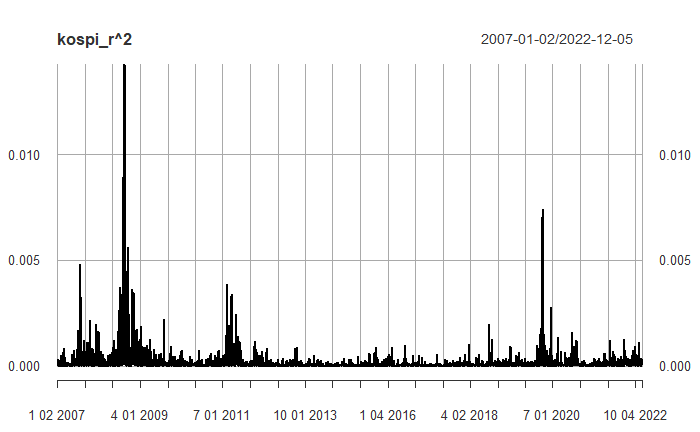

```r
library(FinTS)
library(TSA)
library(quantmod)
# Yahoo! Finance로터 종합주가지수 종가 데이터 가져오기
kospi = getSymbols("^KS11", auto.assign = FALSE)[,4]
kospi_r = dailyReturn(kospi)
plot(kospi_r^2, xlab="", ylab="")
```

#### McLeod and Li 검정

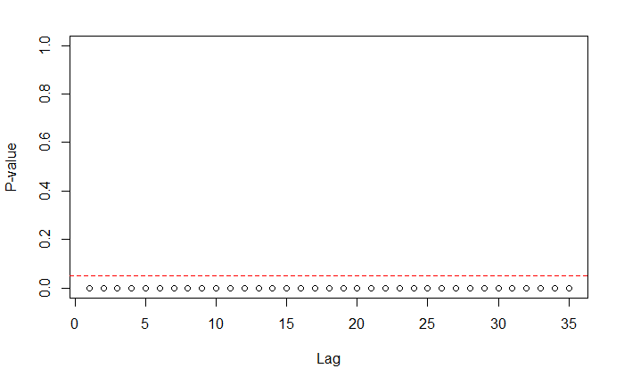

```r
McLeod.Li.test(y=kospi_r)
```

```r
ArchTest(kospi_r, lag=12)
```

```
    ARCH LM-test; Null hypothesis: no ARCH effects

data:  kospi_r
Chi-squared = 1007.7, df = 12, p-value < 2.2e-16
```

#### 그림 5-6 로그변환된 계절조정 GDP와 그 1차 차분계열 추이

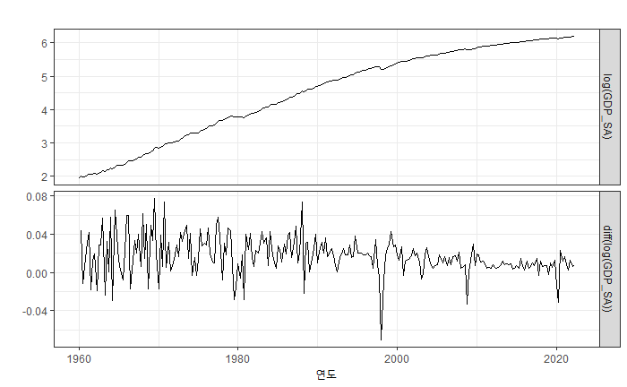

```r
gdp = read_excel("./data/데이터.xlsx", sheet="GDP")
GDP_SA = ts(gdp[,2]/1000, start=1960, frequency=4)
cbind("log(GDP_SA)"=log(GDP_SA), "diff(log(GDP_SA))"=diff(log(GDP_SA))) %>%
autoplot(facets=TRUE) +
    xlab("연도") + ylab("") + ggtitle("") + theme_bw()
```

#### 그림 5-7 로그변환된 GDP 원계열과 그 1차 및 4차 차분계열 추이

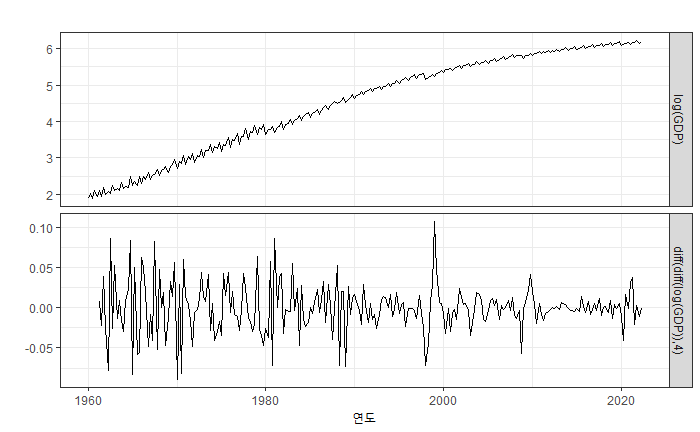

```r
gdp = read_excel("./data/데이터.xlsx", sheet="GDP")
GDP = ts(gdp[,3]/1000, start=1960, frequency=4)
cbind("log(GDP)"=log(GDP), "diff(diff(log(GDP)),4)"=diff(diff(log(GDP)),4)) %>%
autoplot(facets=TRUE) +
    xlab("연도") + ylab("") + ggtitle("") + theme_bw()
```

#### 그림 5-8 로그변환된 종합주가지수 차분계열의 상관도표와 부분상관도표

```r
kospi = read_excel("./data/데이터.xlsx", sheet="주가지수")

kospi_ts = kospi[,2] %>% ts(start=2004, frequency=12) %>% window(start=2010)

kospi_ts %>% log %>% ur.df(type="trend", selectlags ="BIC") %>% summary
```

```
###############################################
# Augmented Dickey-Fuller Test Unit Root Test #
###############################################

Test regression trend


Call:
lm(formula = z.diff ~ z.lag.1 + 1 + tt + z.diff.lag)

Residuals:
      Min        1Q    Median        3Q       Max
-0.199112 -0.016107  0.002159  0.017419  0.102509

Coefficients:
              Estimate Std. Error t value Pr(>|t|)
(Intercept)  0.6700192  0.2311325   2.899  0.00433 **
z.lag.1     -0.0890306  0.0309705  -2.875  0.00465 **
tt           0.0001939  0.0001095   1.771  0.07871 .
z.diff.lag   0.2231554  0.0808058   2.762  0.00650 **
---
Signif. codes:  0 ‘***’ 0.001 ‘**’ 0.01 ‘*’ 0.05 ‘.’ 0.1 ‘ ’ 1

Residual standard error: 0.03675 on 145 degrees of freedom
Multiple R-squared:  0.08739,   Adjusted R-squared:  0.0685
F-statistic: 4.628 on 3 and 145 DF,  p-value: 0.004022


Value of test-statistic is: -2.8747 3.0821 4.3682

Critical values for test statistics:
      1pct  5pct 10pct
tau3 -3.99 -3.43 -3.13
phi2  6.22  4.75  4.07
phi3  8.43  6.49  5.47
```

```r
kospi_ts %>% log %>% ur.df(type="trend") %>% summary
```

```
###############################################
# Augmented Dickey-Fuller Test Unit Root Test #
###############################################

Test regression trend


Call:
lm(formula = z.diff ~ z.lag.1 + 1 + tt + z.diff.lag)

Residuals:
      Min        1Q    Median        3Q       Max
-0.199112 -0.016107  0.002159  0.017419  0.102509

Coefficients:
              Estimate Std. Error t value Pr(>|t|)
(Intercept)  0.6700192  0.2311325   2.899  0.00433 **
z.lag.1     -0.0890306  0.0309705  -2.875  0.00465 **
tt           0.0001939  0.0001095   1.771  0.07871 .
z.diff.lag   0.2231554  0.0808058   2.762  0.00650 **
---
Signif. codes:  0 ‘***’ 0.001 ‘**’ 0.01 ‘*’ 0.05 ‘.’ 0.1 ‘ ’ 1

Residual standard error: 0.03675 on 145 degrees of freedom
Multiple R-squared:  0.08739,   Adjusted R-squared:  0.0685
F-statistic: 4.628 on 3 and 145 DF,  p-value: 0.004022


Value of test-statistic is: -2.8747 3.0821 4.3682

Critical values for test statistics:
      1pct  5pct 10pct
tau3 -3.99 -3.43 -3.13
phi2  6.22  4.75  4.07
phi3  8.43  6.49  5.47
```

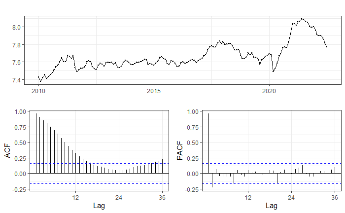

```r
kospi_ts  %>% log %>% ggtsdisplay(main="", theme=theme_bw())
```

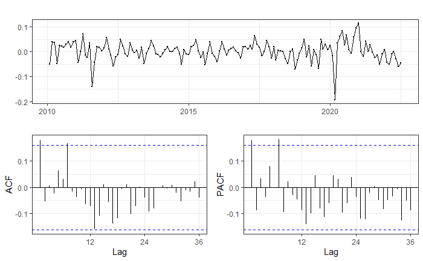

```r
kospi_ts  %>% log %>% diff %>% ggtsdisplay(main="", theme=theme_bw())
```

#### 그림 5-9 로그변환된 GDP 원계열의 1차, 4차 차분계열의 상관도표와 부분상관도표

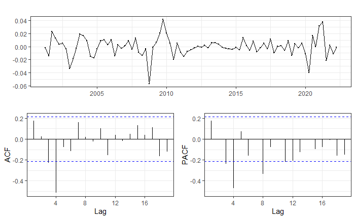

```r
gdp = read_excel("./data/데이터.xlsx", sheet="GDP")
GDP = ts(gdp[,3]/1000, start=1960, frequency=4) %>% window(start=2000)
DL_GDP = diff(diff(log(GDP),4))
DL_GDP %>% ggtsdisplay(main="", theme=theme_bw())
```

#### 그림 5-10 로그변환된 종합주가지수의 ARIMA 모형 추정결과

#### <프로그램 5-2>

```r
kospi = read_excel("./data/데이터.xlsx", sheet="주가지수")

kospi_ts = kospi[,2] %>% ts(start=2004, frequency=12)  %>% window(start=2010)

kospi_ts  %>% log %>% Arima(order=c(1,1,1))
```

```
Series: .
ARIMA(1,1,1)

Coefficients:
          ar1     ma1
      -0.6820  0.8634
s.e.   0.1586  0.1135

sigma^2 = 0.001387:  log likelihood = 281.6
AIC=-557.2   AICc=-557.03   BIC=-548.16
```

```r
kospi_ts  %>% log %>% Arima(order=c(0,1,1))
```

```
Series: .
ARIMA(0,1,1)

Coefficients:
         ma1
      0.2179
s.e.  0.0867

sigma^2 = 0.001407:  log likelihood = 280.15
AIC=-556.3   AICc=-556.21   BIC=-550.27
```

```r
kospi_ts  %>% log %>% Arima(order=c(1,1,0))
```

```
Series: .
ARIMA(1,1,0)

Coefficients:
         ar1
      0.1846
s.e.  0.0808

sigma^2 = 0.001415:  log likelihood = 279.7
AIC=-555.4   AICc=-555.31   BIC=-549.37
```

```r
#kospi_ts  %>% log %>% auto.arima(seasonal = FALSE)
```

#### 그림 5-11 로그변환된 종합주가지수의 ARIMA 모형 과대적합진단

#### <프로그램 5-2> 계속

```r
kospi_ts  %>% log %>% Arima(order=c(1,1,1))
```

```
Series: .
ARIMA(1,1,1)

Coefficients:
          ar1     ma1
      -0.6820  0.8634
s.e.   0.1586  0.1135

sigma^2 = 0.001387:  log likelihood = 281.6
AIC=-557.2   AICc=-557.03   BIC=-548.16
```

```r
kospi_ts  %>% log %>% Arima(order=c(1,1,2))
```

```
Series: .
ARIMA(1,1,2)

Coefficients:
          ar1     ma1    ma2
      -0.9107  1.1600  0.160
s.e.   0.0434  0.0983  0.095

sigma^2 = 0.001366:  log likelihood = 282.33
AIC=-556.66   AICc=-556.39   BIC=-544.62
```

```r
kospi_ts  %>% log %>% Arima(order=c(2,1,1))
```

```
Series: .
ARIMA(2,1,1)

Coefficients:
          ar1     ar2     ma1
      -0.7060  0.0980  0.9337
s.e.   0.1598  0.1139  0.1376

sigma^2 = 0.001388:  log likelihood = 282.05
AIC=-556.1   AICc=-555.83   BIC=-544.06
```

```
    Ljung-Box test

data:  Residuals from ARIMA(1,1,1)
Q* = 18.23, df = 22, p-value = 0.6923

Model df: 2.   Total lags used: 24
```

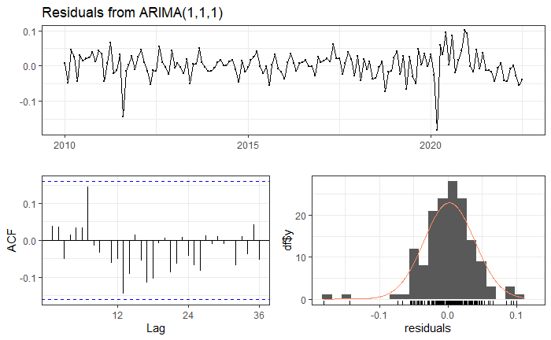

```r
kospi_ts %>% log %>% Arima(order=c(1,1,1)) %>% checkresiduals(main="", theme=theme_bw())
```

#### 그림 5-13 로그변환된 종합주가지수 추정모형을 이용한 예측

#### <프로그램 5-2> 계속

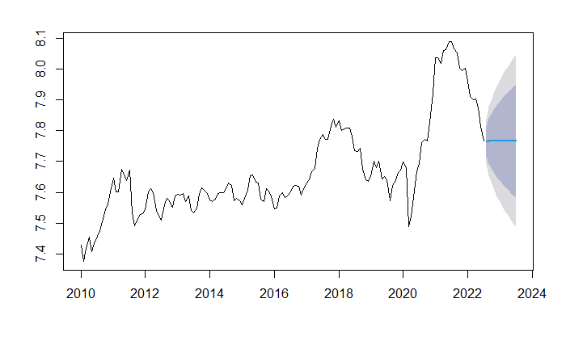

```r
kospi_ts %>% log %>% Arima(order=c(1,1,1)) %>% forecast(h=12)  %>% plot(main="")
```

#### 그림 5-14 일별 종합주가지수 로그수익률의 히스토그램과 정규성 검정

```r
library(TSA)
library(tseries)
library(quantmod)
library(fGarch)

s_date = as.Date('2007-01-01')
e_date = as.Date('2022-08-31')

getSymbols("^KS11", from=s_date, to=e_date)
```

```
[1] "^KS11"
```

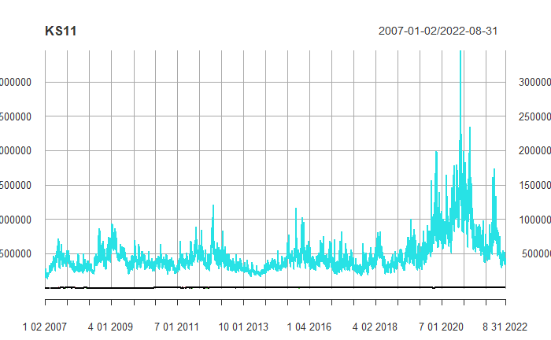

```r
 plot(KS11)
```

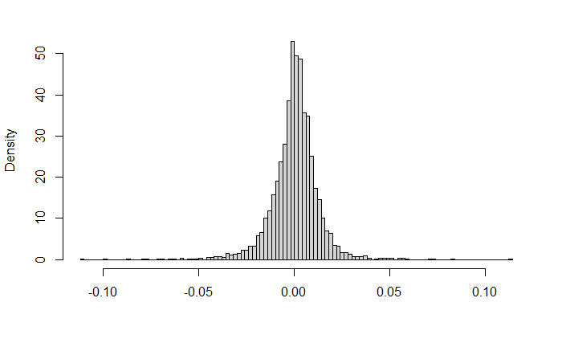

```r
 kospi =KS11$ KS11.Close
 r.kospi = diff(log(kospi))
 r.kospi1 = r.kospi[2:length(r.kospi)]

 #plot(kospi, main="KOSPI")
 #plot(r.kospi, main="dlog KOSPI")

 hist(r.kospi1, breaks=100, freq=FALSE, main ="", xlab="")
```

```r
 #qqnorm(r.kospi1)
 #qqline(r.kospi1)
 #jarque.bera.test(na.omit(r.kospi1))
 #kurtosis(r.kospi1)
 #skewness(r.kospi1)
```

#### 그림 5-15 종합주가지수 로그수익률 및 로그수익률 제곱의 상관도표․부분상관도표

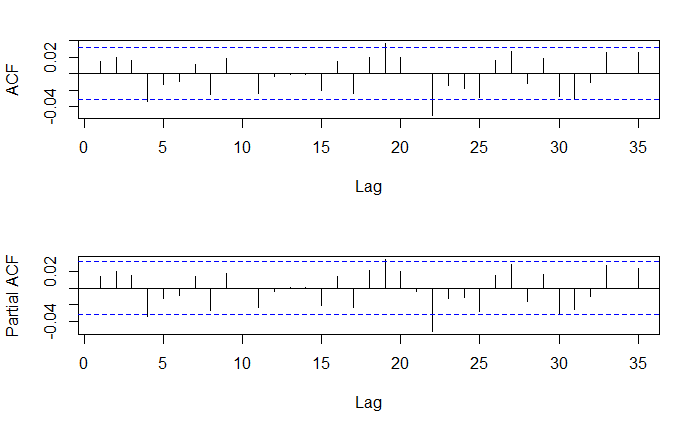

```r
par(mfrow=c(2,1))
 acf(r.kospi, na.action = na.pass, main ="")
 pacf(r.kospi, na.action = na.pass, main ="")
```

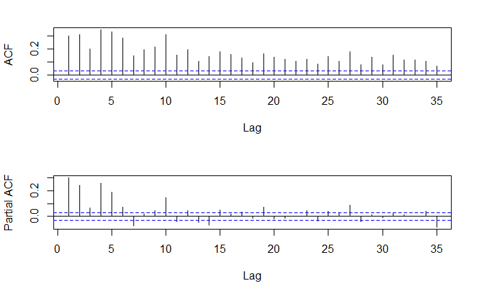

```r
 acf(r.kospi^2, na.action = na.pass, main ="")
 pacf(r.kospi^2, na.action = na.pass, main ="")
```

```r
 #McLeod.Li.test(y=r.kospi)
```

#### 그림 5-16 GARCH 모형 추정결과

#### <프로그램 5-3>

```r
library(quantmod)
library(rugarch)

s_date = as.Date('2007-01-01')
e_date = as.Date('2022-08-31')

getSymbols("^KS11", from=s_date, to=e_date)
```

```
[1] "^KS11"
```

```r
kospi =KS11$ KS11.Close
r.kospi = diff(log(kospi))

spec3 = ugarchspec(variance.model=list(model="sGARCH", garchOrder=c(1,1)),
        mean.model=list(armaOrder=c(0,0), include.mean=TRUE),
        distribution.model="norm")

fit = ugarchfit(data = na.omit(r.kospi), spec = spec3)
fit
```

```
*---------------------------------*
*          GARCH Model Fit        *
*---------------------------------*

Conditional Variance Dynamics
-----------------------------------
GARCH Model : sGARCH(1,1)
Mean Model  : ARFIMA(0,0,0)
Distribution    : norm

Optimal Parameters
------------------------------------
        Estimate  Std. Error  t value Pr(>|t|)
mu      0.000333    0.000143   2.3332 0.019638
omega   0.000002    0.000001   1.6360 0.101849
alpha1  0.088689    0.014110   6.2856 0.000000
beta1   0.898058    0.015018  59.7984 0.000000

Robust Standard Errors:
        Estimate  Std. Error  t value Pr(>|t|)
mu      0.000333    0.000139  2.38668 0.017001
omega   0.000002    0.000007  0.27213 0.785520
alpha1  0.088689    0.071994  1.23188 0.217992
beta1   0.898058    0.080616 11.14001 0.000000

LogLikelihood : 12241.4

Information Criteria
------------------------------------

Akaike       -6.3505
Bayes        -6.3440
Shibata      -6.3505
Hannan-Quinn -6.3482

Weighted Ljung-Box Test on Standardized Residuals
------------------------------------
                        statistic p-value
Lag[1]                      2.257  0.1330
Lag[2*(p+q)+(p+q)-1][2]     3.059  0.1352
```

[output cut: 19 more lines]

```
Nyblom stability test
------------------------------------
Joint Statistic:  90.3286
Individual Statistics:
mu      0.2031
omega  16.3249
alpha1  0.5525
beta1   0.6359

Asymptotic Critical Values (10% 5% 1%)
Joint Statistic:         1.07 1.24 1.6
Individual Statistic:    0.35 0.47 0.75

Sign Bias Test
------------------------------------
```

|  | t-value | prob | sig |
| --- | --- | --- | --- |
| Sign Bias | 0.613807 | 5.393791e-01 |  |
| Negative Sign Bias | 3.369029 | 7.617545e-04 | *** |
| Positive Sign Bias | 3.497162 | 4.755523e-04 | *** |
| Joint Effect | 51.158706 | 4.525653e-11 | *** |

```
Adjusted Pearson Goodness-of-Fit Test:
------------------------------------
  group statistic p-value(g-1)
1    20     131.1    8.960e-19
2    30     162.5    1.615e-20
3    40     188.3    1.908e-21
4    50     204.3    7.255e-21


Elapsed time : 0.2863019
```

```r
plot(fit) # 3번 선택
```

```
Make a plot selection (or 0 to exit):

 1:   Series with 2 Conditional SD Superimposed
 2:   Series with 1% VaR Limits
 3:   Conditional SD (vs |returns|)
 4:   ACF of Observations
 5:   ACF of Squared Observations
 6:   ACF of Absolute Observations
 7:   Cross Correlation
 8:   Empirical Density of Standardized Residuals
 9:   QQ-Plot of Standardized Residuals
10:   ACF of Standardized Residuals
11:   ACF of Squared Standardized Residuals
12:   News-Impact Curve
```

```r
1
```

```
Make a plot selection (or 0 to exit):

 1:   Series with 2 Conditional SD Superimposed
 2:   Series with 1% VaR Limits
 3:   Conditional SD (vs |returns|)
 4:   ACF of Observations
 5:   ACF of Squared Observations
 6:   ACF of Absolute Observations
 7:   Cross Correlation
 8:   Empirical Density of Standardized Residuals
 9:   QQ-Plot of Standardized Residuals
10:   ACF of Standardized Residuals
11:   ACF of Squared Standardized Residuals
12:   News-Impact Curve
```

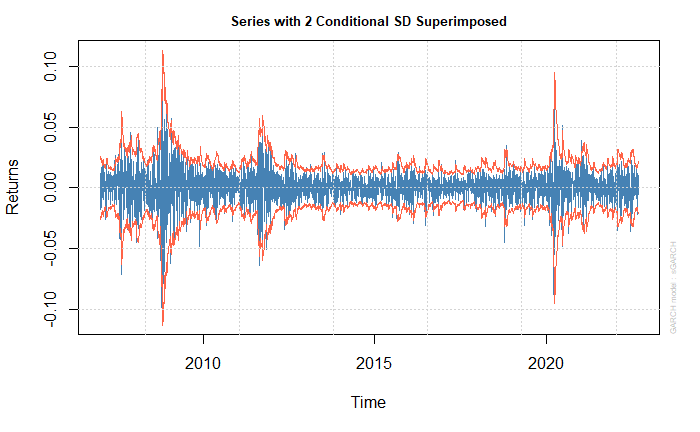

```r
0
```

```r
forc = ugarchforecast(fit, n.ahead=50)
plot(forc) # 3번 선택
```

```
Make a plot selection (or 0 to exit):

1:   Time Series Prediction (unconditional)
2:   Time Series Prediction (rolling)
3:   Sigma Prediction (unconditional)
4:   Sigma Prediction (rolling)
```

```r
3
```

```
Make a plot selection (or 0 to exit):

1:   Time Series Prediction (unconditional)
2:   Time Series Prediction (rolling)
3:   Sigma Prediction (unconditional)
4:   Sigma Prediction (rolling)
```

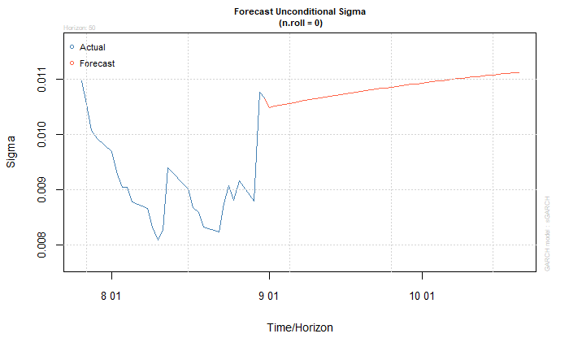

```
Make a plot selection (or 0 to exit):

1:   Time Series Prediction (unconditional)
2:   Time Series Prediction (rolling)
3:   Sigma Prediction (unconditional)
4:   Sigma Prediction (rolling)
```

```r
3
```

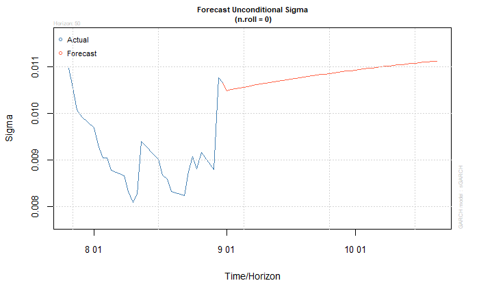

```r
0
```

```r
#head(sigma(forc))
#head(fitted(forc))
```